# Age restricted DTI analysis using stripped files

Let’s first plot the DTI results we’re comparing to, before we do the age restriction analysis:

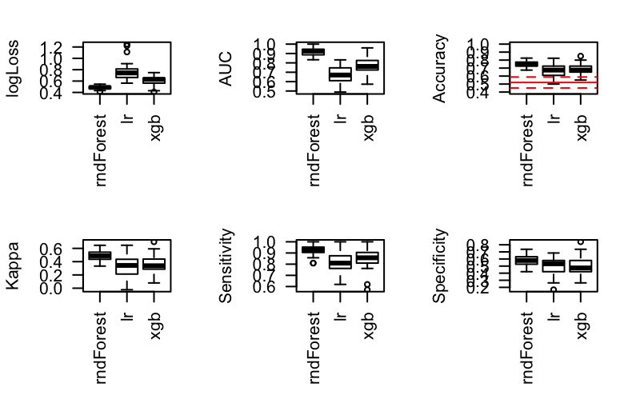

```r
source('~/ncr_notebooks/baseline_prediction/src/aux_functions.R')
root_fname = '~/data/baseline_prediction/results/stripped_allDTI_NVvsADHD_big'
do_metrics_plots(root_fname)
```

Now we can run a series of age restrictions to the data, and see if it gets better or worse:

```r
tract_data = read.csv('~/data/baseline_prediction/stripped/dti.csv')
rm_me = (tract_data$fa_avg < .4 | tract_data$ad_avg < 1.18 | tract_data$rd_avg > .65 | tract_data$rd_avg < .5 |
         tract_data$norm.trans > .45 | tract_data$norm.rot > .008 | tract_data$goodSlices < 45 | tract_data$goodSlices > 70)
print(sprintf('Reducing from %d to %d scans', nrow(tract_data), nrow(tract_data)-sum(rm_me)))
```

```
[1] "Reducing from 727 to 656 scans"
```

```r
tract_data = tract_data[!rm_me, ]
gf_fname = '~/data/baseline_prediction/stripped/clinical.csv'
gf = read.csv(gf_fname)
gf = gf[gf$BASELINE=='BASELINE', ]
my_ids = intersect(gf$MRN, tract_data$MRN)
merged = mergeOnClosestDate(gf, tract_data, my_ids)
rm_me = abs(merged$dateX.minus.dateY.months) > 12
print(sprintf('Reducing from %d to %d scans', nrow(merged), nrow(merged)-sum(rm_me)))
```

```
[1] "Reducing from 289 to 200 scans"
```

```r
merged = merged[!rm_me, ]
```

```r
library(caret)
library(randomForest)
seed = 107
phen_vars = c(which(grepl("^FA_", colnames(merged))),
              which(grepl("^AD_", colnames(merged))),
              which(grepl("^RD_", colnames(merged))),
              which(grepl("^MO_", colnames(merged)))
              )
X = merged[, phen_vars]
y = merged$DX_BASELINE
y[y != 'NV'] = 'ADHD'
y = factor(y)
```

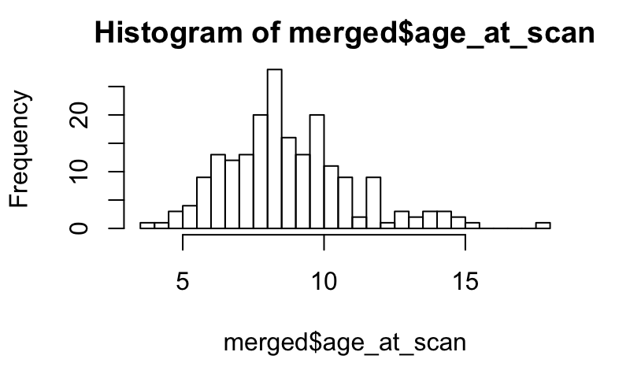

```r
hist(merged$age_at_scan, breaks=40)
```

Just based on the histogram, let’s start cutting off anyone above 13, then we go down to assess a few more theory-inspired cutoffs:

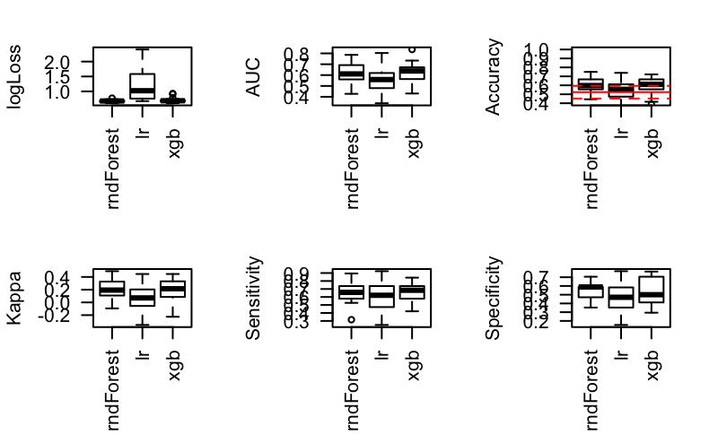

```r
# rm_me = (merged$age_at_scan > 13) | (rowSums(is.na(X)) > 0)
# ldata = X[!rm_me, ]
# groups = y[!rm_me]
root_fname = '~/data/baseline_prediction/results/stripped_allDTISE13_NVvsADHD'
# save(ldata, groups, file=sprintf('%s.RData', root_fname), compress=T)
# #runInCluster(root_fname, train_test_ratio=.8, cpuDiff=0, nsplits=30, nrepeatcv=5, run_models=c('rndForest', 'lr', 'xgb'))
#
do_metrics_plots(root_fname)
```

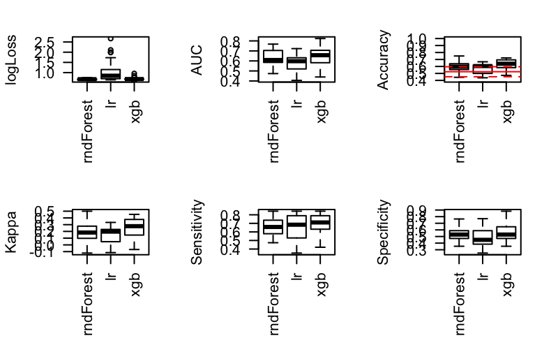

```r
# rm_me = (merged$age_at_scan > 12) | (rowSums(is.na(X)) > 0)
# ldata = X[!rm_me, ]
# groups = y[!rm_me]
root_fname = '~/data/baseline_prediction/results/stripped_allDTISE12_NVvsADHD'
# save(ldata, groups, file=sprintf('%s.RData', root_fname), compress=T)
# #runInCluster(root_fname, train_test_ratio=.8, cpuDiff=0, nsplits=30, nrepeatcv=5, run_models=c('rndForest', 'lr', 'xgb'))
#
do_metrics_plots(root_fname)
```

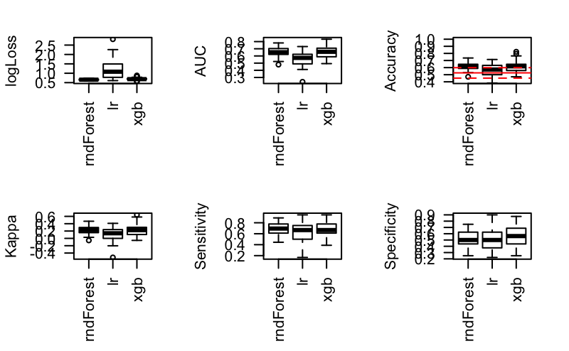

```r
# rm_me = (merged$age_at_scan > 11) | (rowSums(is.na(X)) > 0)
# ldata = X[!rm_me, ]
# groups = y[!rm_me]
root_fname = '~/data/baseline_prediction/results/stripped_allDTISE11_NVvsADHD'
# save(ldata, groups, file=sprintf('%s.RData', root_fname), compress=T)
#runInCluster(root_fname, train_test_ratio=.8, cpuDiff=0, nsplits=30, nrepeatcv=5, run_models=c('rndForest', 'lr', 'xgb'))
do_metrics_plots(root_fname)
```

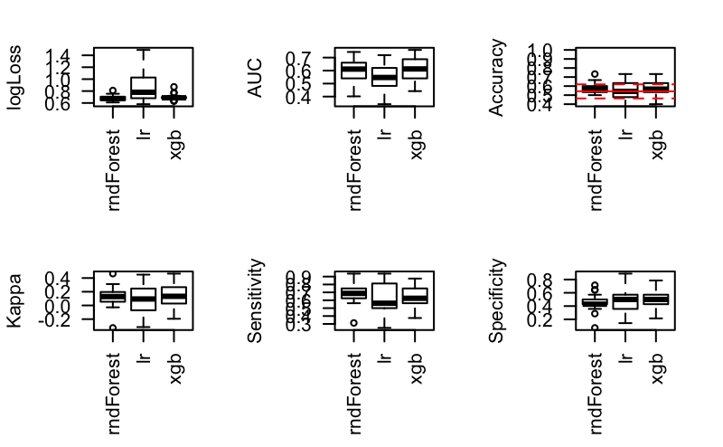

```r
# rm_me = (merged$age_at_scan > 10) | (rowSums(is.na(X)) > 0)
# ldata = X[!rm_me, ]
# groups = y[!rm_me]
root_fname = '~/data/baseline_prediction/results/stripped_allDTISE10_NVvsADHD'
# save(ldata, groups, file=sprintf('%s.RData', root_fname), compress=T)
#runInCluster(root_fname, train_test_ratio=.8, cpuDiff=0, nsplits=30, nrepeatcv=5, run_models=c('rndForest', 'lr', 'xgb'))
do_metrics_plots(root_fname)
```

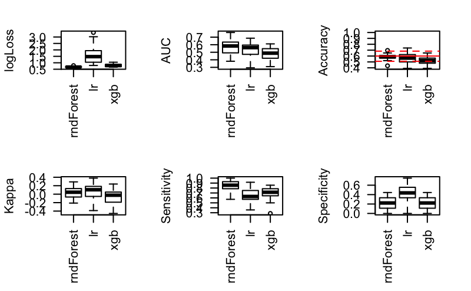

```r
# rm_me = (merged$age_at_scan > 9) | (rowSums(is.na(X)) > 0)
# ldata = X[!rm_me, ]
# groups = y[!rm_me]
root_fname = '~/data/baseline_prediction/results/stripped_allDTISE9_NVvsADHD'
# save(ldata, groups, file=sprintf('%s.RData', root_fname), compress=T)
#
#runInCluster(root_fname, train_test_ratio=.8, cpuDiff=0, nsplits=30, nrepeatcv=5, run_models=c('rndForest', 'lr', 'xgb'))
do_metrics_plots(root_fname)
```

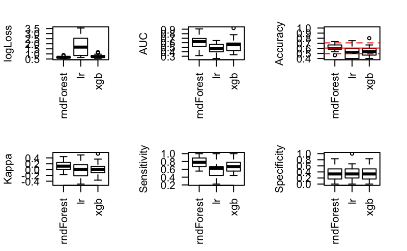

```r
# rm_me = (merged$age_at_scan > 8) | (rowSums(is.na(X)) > 0)
# ldata = X[!rm_me, ]
# groups = y[!rm_me]
root_fname = '~/data/baseline_prediction/results/stripped_allDTISE8_NVvsADHD'
# save(ldata, groups, file=sprintf('%s.RData', root_fname), compress=T)
#runInCluster(root_fname, train_test_ratio=.8, cpuDiff=0, nsplits=30, nrepeatcv=5, run_models=c('rndForest', 'lr', 'xgb'))
do_metrics_plots(root_fname)
```

The results are a bit concerning. It looks like we need all that data, in particular the data from the older kids, in order to make a baseline prediction. Not sure how clinically informative that is. Should we try to really fit our models within the < 8 y.o range, and then expand it?

The trick is that I only have 76 scans < 8, but 120 < 9. That’s a more manageable number that we could work with in better fitting classifiers.

Another way of getting more scans would be to possibly derive the visual thresholds from histograms in the age subgroups. Maybe that would savage some of the data?

# Deeper exploring of < 9 y.o. scans

What does the histogram look like?

```r
tract_data = read.csv('~/data/baseline_prediction/stripped/dti.csv')
tract_data = tract_data[tract_data$age_at_scan <= 9, ]
par(mfrow=c(2, 3))
nbreaks = 40
hist(tract_data$fa_avg, breaks=nbreaks)
hist(tract_data$ad_avg, breaks=nbreaks)
```

[output not shown]

```r
hist(tract_data$rd_avg, breaks=nbreaks)
hist(tract_data$norm.trans, breaks=nbreaks)
```

[output not shown]

[figure not shown]

```r
hist(tract_data$norm.rot, breaks=nbreaks)
hist(tract_data$goodSlices, breaks=nbreaks)
```

It turns out that it doesn’t make that much difference in the cut-offs, at least visually.

```r
rm_me = (tract_data$fa_avg < .4 | tract_data$ad_avg < 1.18 | tract_data$rd_avg > .65 | tract_data$rd_avg < .5 |
         tract_data$norm.trans > .45 | tract_data$norm.rot > .008 | tract_data$goodSlices < 45 | tract_data$goodSlices > 70)
print(sprintf('Reducing from %d to %d scans', nrow(tract_data), nrow(tract_data)-sum(rm_me)))
```

```
[1] "Reducing from 304 to 269 scans"
```

```r
tract_data = tract_data[!rm_me, ]
```

```r
gf_fname = '~/data/baseline_prediction/stripped/clinical.csv'
gf = read.csv(gf_fname)
gf = gf[gf$BASELINE=='BASELINE', ]
my_ids = intersect(gf$MRN, tract_data$MRN)
merged = mergeOnClosestDate(gf, tract_data, my_ids)
rm_me = abs(merged$dateX.minus.dateY.months) > 12
print(sprintf('Reducing from %d to %d scans', nrow(merged), nrow(merged)-sum(rm_me)))
```

```
[1] "Reducing from 173 to 120 scans"
```

```r
merged = merged[!rm_me, ]
```

OK, so we arrived at the same number as before. Do we have any NAs?

```r
phen_vars = c(which(grepl("^FA_", colnames(merged))),
              which(grepl("^AD_", colnames(merged))),
              which(grepl("^RD_", colnames(merged))),
              which(grepl("^MO_", colnames(merged)))
              )
X = merged[, phen_vars]
y = merged$DX_BASELINE
y[y != 'NV'] = 'ADHD'
y = factor(y)
sum(rowSums(is.na(X)) > 0)
```

```
[1] 0
```

Nope. Now, let’s do a more in-depth study of this data using Random Forests:

```r
library(caret)
library(randomForest)
seed = 107
inTraining <- createDataPartition(y, p = .75, list = FALSE)
training <- cbind(X[ inTraining,], y[inTraining])
testing  <- cbind(X[-inTraining,], y[-inTraining])
colnames(training)[ncol(X) + 1] = 'Class'
colnames(testing)[ncol(X) + 1] = 'Class'
```

```r
fitControl <- trainControl(## 10-fold CV
                           method = "oob",
                           number = 10,
                           ## repeated ten times
                           repeats = 10)
set.seed(seed)
rndForestGrid <- expand.grid(.mtry=c(1:sqrt(ncol(X))))
myFit <- train(Class ~ ., data = training,
                 method = "rf",
                 trControl = fitControl,
               tuneGrid=rndForestGrid,
               # search='grid',
               # tuneLength=10,
               preProcess = c('nzv', 'pca'),
              verbose=F)
myFit
```

[output not shown]

It doesn’t look like we’re going to improve much here… let’s see how well we do with xgb though:

```r
fitControl <- trainControl(## 10-fold CV
                           method = "repeatedcv",
                           number = 10,
                           ## repeated ten times
                           repeats = 10)
set.seed(seed)
myFit <- train(Class ~ ., data = training,
                 method = "xgbTree",
                 trControl = fitControl,
               # tuneGrid=rndForestGrid,
               search='grid',
               tuneLength=10,
               preProcess = c('nzv', 'pca'),
              verbose=F)
myFit
```

[output not shown]

Also not great…